# Stats for Data Science

Joint Mathematics Meetings January 18, 2020

## *Modernizing*

> mod·ern·ize | ˈmädərˌnīz |

> *verb [with object]*

> adapt (something) to modern needs or habits, typically by installing modern equipment or adopting modern ideas or methods: *a five-year plan to modernize Algerian agriculture*.

## Modernizing Needs

modern needs

- prediction/classification
- decision making/trade-offs
- causality

pre-modern needs

- detect some signal in noise: averaging
- infer genetics from phenotypes: \(r\)
- provide arbitration for claims: \(p\)

## Modernizing Equipment

modern equipment

- computers
- databases
- high connectivity

pre-modern equipment

- mechanical calculators
- static tables and tabulations
- printing as distribution

## Modernizing Methods

modern methods

- wrangling & visualization
- machine/statistical learning
- randomization, bootstrapping, cross-validation
- directed acyclic graphs
- false discovery rates, …

pre-modern methods

- see, e.g. most intro stats books
- correlation/simple regression
- histograms

## Modernizing pedagogy

Many excellent recommendations from GAISE and other sources.

I have one more to add, that I think is critical:

Base teaching on what we know now, not on what was being invented in 1880-1910.

**Ontogeny recapitulates phylogeny?**

In biology: Growth and development of an individual follows the same path as the evolution of a species.

[figure not shown]

## Should statistics teaching follow embryology?

In education: Should individual students follow the same path as statistics as a whole?

Bernoulli \(\Rightarrow\) Gauss \(\Rightarrow\)

Quetelet \(\Rightarrow\) Galton \(\Rightarrow\)

Pearson \(\Rightarrow\) Gosset \(\Rightarrow\)

Fisher \(\Rightarrow\)

Neyman-Pearson …

probability, means,

standard deviation,

correlation coefficient,

chi-squared,

t-test, “significant”, “p-value”, …

## If statistics were automobiles … 1880s

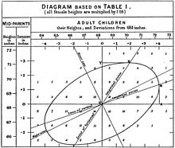

1888 Francis Galton introduces the “co-relation” coefficient

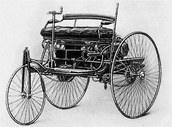

1885 Karl Benz designs 4-stroke engine for use in his automobile

## If statistics were automobiles … 1900–1910

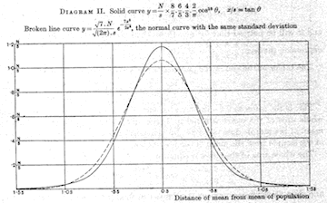

1908 William Gossett’s t statistic

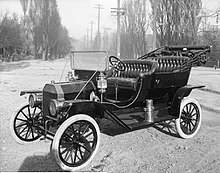

1908 First Model T off Henry Ford’s production line

## If statistics were automobiles … 1920s

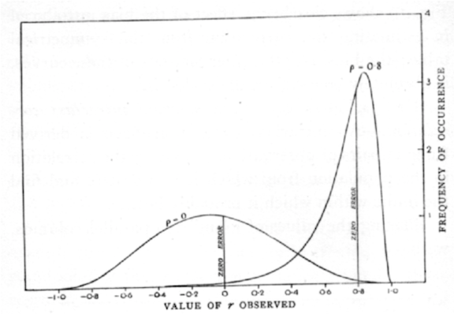

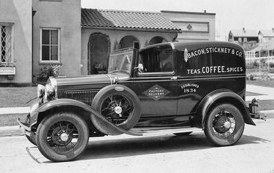

## Where does following the historical path get us?

- introductory course typically ends at or before “one-way” ANOVA
- we neglect thinking constructively about causation
  - we end up like Fisher in 1959 arguing that smoking doesn’t cause cancer
- we avoid problems of prediction, researcher degrees of freedom, false discovery, evaluating trade-offs

## Detours on the path to data science

We dip into historical coves and specialized techniques

- chi-squared, unequal variance t-test, one-tailed tests, histogram, stem-and-leaf, box-and-whisker
- we use historical vocabulary that can be offputting or misleading
  - standard deviation, standard error, margin of error, significance

## Proposal: Stats for Data Science

Let’s work backward from current needs: prediction, decision-making, causality.

Meet these needs without worrying about phylogeny and history.

## A curriculum, with only the essentials:

1. Data organization
2. Graphics
3. Models (generalize graphics to many variables)
   - present “hypothesis testing” as aiding decision making when model building
4. … leaving time for covariates, causality, loss-functions & trade-offs, models that learn, …

## Computing essentials

How can we make computing accessible to everyone, both practically and intellectually?

**Practical**: Browser-based applications, web apps

**Intellectual**: Define a small set of essential, high-level skills.

## Essential, high-level computing skills

1. Draw a point plot. Up to four variables: y, x, color, facet.
   - use jittering and transparency
2. Construct a model: `y ~ x + z` and visualize it with (1).
   - allow flexibility
   - allow choice of architectures: machine-learning, bounded, unbounded.
3. Evaluate a model at two different inputs: effect size
4. Compare two models, e.g. `y ~ 1` and `y ~ 1 + x`
   - cross-validated prediction error
   - F

One app can do all these things in the space of a smartphone.

## 1. Create a model

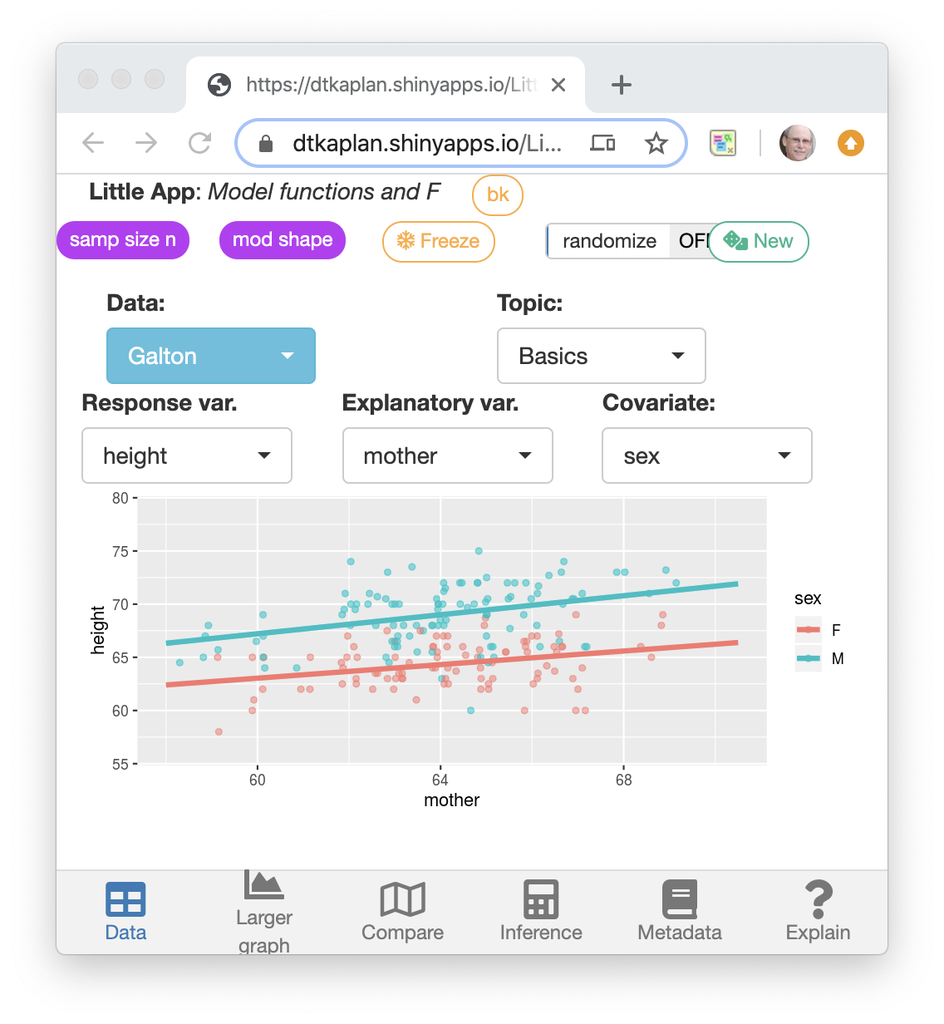

## 2. Evaluate and find effect size

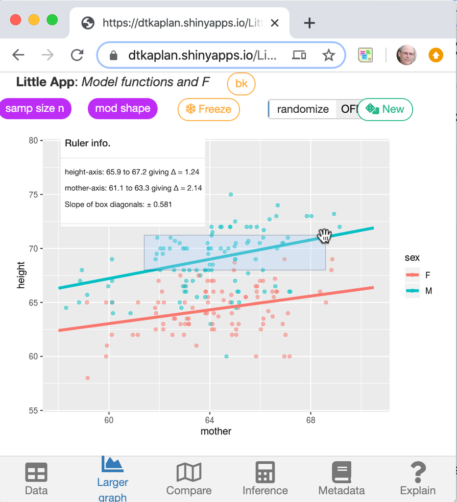

## 3. Compare models

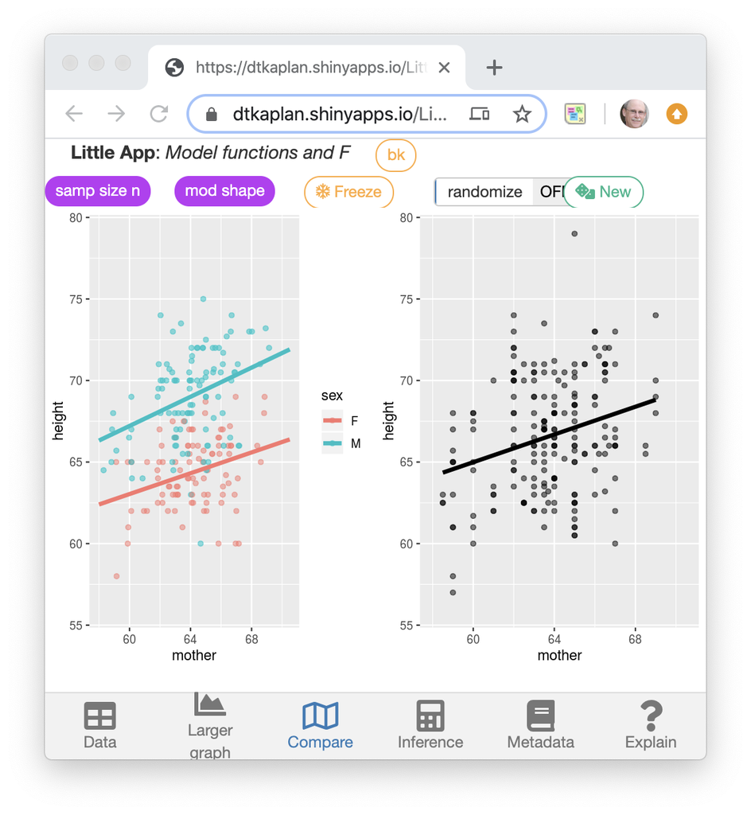

## 4. Inference for comparing models

[figure not shown]

## *A Compact Guide to Classical Inference*

*How to help instructors who are in a math environment where computing is deprecated and formulas are seen as the “real math”?*

Being serialized at StatPREP.org

Short book for instructors showing

1. How to unify all the inference settings into a single method
2. … that doesn’t require any computation besides the app
3. … that builds confidence since approximate results can be seen by eye, and
4. exact results use 1 simple formula

## Resources

- `StatPREP.org`: Little Apps and *Compact Guide*
- MAA mini-course in *Stats for Data Science*: `dtkaplan.github.io/SDS-MAA-minicourse`
- Draft of more extensive textbook: `dtkaplan.github.io/SDS-book`
- The prototype app in the slides: `dtkaplan.shinyapps.io/LittleAppF`